# Relación ejercicios Tema 2

Alumno: Inmaculada Perea Fernández

(09/12/2016)

**Ejemplo 1.- Considerar el conjunto de datos ChickWeight de R (data(ChickWeight)), que contiene el peso frente a la edad de 50 polluelos en diferentes días en cuatro dietas. La variable weight indica el peso, la variable Time indica la edad en días (a los 0 días, 2,4,…,20 y 21, si vive), la variable Chick indica el polluelo bajo estudio y la variable Diet indica la dieta seguida**

Lectura y preparación de los datos

```r
#?ChickWeight
names(ChickWeight)
```

```
## [1] "weight" "Time"   "Chick"  "Diet"
```

```r
str(ChickWeight)
```

```
## Classes 'nfnGroupedData', 'nfGroupedData', 'groupedData' and 'data.frame':   578 obs. of  4 variables:
##  $ weight: num  42 51 59 64 76 93 106 125 149 171 ...
##  $ Time  : num  0 2 4 6 8 10 12 14 16 18 ...
##  $ Chick : Ord.factor w/ 50 levels "18"<"16"<"15"<..: 15 15 15 15 15 15 15 15 15 15 ...
##  $ Diet  : Factor w/ 4 levels "1","2","3","4": 1 1 1 1 1 1 1 1 1 1 ...
##  - attr(*, "formula")=Class 'formula'  language weight ~ Time | Chick
##   .. ..- attr(*, ".Environment")=<environment: R_EmptyEnv>
##  - attr(*, "outer")=Class 'formula'  language ~Diet
##   .. ..- attr(*, ".Environment")=<environment: R_EmptyEnv>
##  - attr(*, "labels")=List of 2
##   ..$ x: chr "Time"
##   ..$ y: chr "Body weight"
##  - attr(*, "units")=List of 2
##   ..$ x: chr "(days)"
##   ..$ y: chr "(gm)"
```

```r
head(ChickWeight)
```

```
##   weight Time Chick Diet
## 1     42    0     1    1
## 2     51    2     1    1
## 3     59    4     1    1
## 4     64    6     1    1
## 5     76    8     1    1
## 6     93   10     1    1
```

**1. Calcular la tabla de frecuencias absolutas de cada una de las variables que componen los datos**

```r
FrecAbs_weight <- table(ChickWeight$weight)
print(knitr::kable(as.data.frame(FrecAbs_weight), format = "markdown",
                   col.names = c("Peso (gr)","Frec. absoluta"),align='c',
                   caption="Tabla Frecuencias absolutas Peso"))
```

```
##
##
## | Peso (gr) | Frec. absoluta |
## |:---------:|:--------------:|
## |    35     |       1        |
## |    39     |       8        |
## |    40     |       5        |
## |    41     |       20       |
## |    42     |       15       |
## |    43     |       4        |
## |    44     |       1        |
## |    45     |       1        |
## |    46     |       2        |
## |    47     |       1        |
## |    48     |       8        |
## |    49     |       13       |
## |    50     |       6        |
## |    51     |       8        |
## |    52     |       4        |
## |    53     |       5        |
## |    54     |       3        |
## |    55     |       5        |
## |    56     |       4        |
## |    57     |       3        |
## |    58     |       5        |
## |    59     |       5        |
## |    60     |       2        |
## |    61     |       7        |
## |    62     |       8        |
## |    63     |       5        |
## |    64     |       5        |
## |    65     |       5        |
## |    66     |       4        |
## |    67     |       5        |
## |    68     |       6        |
## |    69     |       1        |
## |    70     |       2        |
## |    71     |       6        |
## |    72     |       6        |
## |    73     |       5        |
```

[output cut: 161 more lines]

```
## |    294    |       1        |
## |    295    |       1        |
## |    303    |       1        |
## |    305    |       2        |
## |    307    |       1        |
## |    309    |       1        |
## |    318    |       1        |
## |    321    |       1        |
## |    322    |       1        |
## |    327    |       1        |
## |    331    |       1        |
## |    332    |       1        |
## |    341    |       1        |
## |    361    |       1        |
## |    373    |       1        |
```

```r
FrecAbs_time <- table(ChickWeight$Time)
print(knitr::kable(as.data.frame(FrecAbs_time), format = "markdown",
                   col.names = c("Edad (días)","Frec. absoluta"),align='c',
                   caption="Tabla Frecuencias absolutas Edad"))
```

```
##
##
## | Edad (días) | Frec. absoluta |
## |:-----------:|:--------------:|
## |      0      |       50       |
## |      2      |       50       |
## |      4      |       49       |
## |      6      |       49       |
## |      8      |       49       |
## |     10      |       49       |
## |     12      |       49       |
## |     14      |       48       |
## |     16      |       47       |
## |     18      |       47       |
## |     20      |       46       |
## |     21      |       45       |
```

```r
FrecAbs_chick <- table(ChickWeight$Chick)
print(knitr::kable(as.data.frame(FrecAbs_chick), format = "markdown",
                   col.names = c("Polluelo","Frec. absoluta"),align='c',
                   caption="Polluelos"))
```

```
##
##
## | Polluelo | Frec. absoluta |
## |:--------:|:--------------:|
## |    18    |       2        |
## |    16    |       7        |
## |    15    |       8        |
## |    13    |       12       |
## |    9     |       12       |
## |    20    |       12       |
## |    10    |       12       |
## |    8     |       11       |
## |    17    |       12       |
## |    19    |       12       |
## |    4     |       12       |
## |    6     |       12       |
## |    11    |       12       |
## |    3     |       12       |
## |    1     |       12       |
## |    12    |       12       |
## |    2     |       12       |
## |    5     |       12       |
## |    14    |       12       |
## |    7     |       12       |
## |    24    |       12       |
## |    30    |       12       |
## |    22    |       12       |
## |    23    |       12       |
## |    27    |       12       |
## |    28    |       12       |
## |    26    |       12       |
## |    25    |       12       |
## |    29    |       12       |
## |    21    |       12       |
## |    33    |       12       |
## |    37    |       12       |
## |    36    |       12       |
## |    31    |       12       |
## |    39    |       12       |
## |    38    |       12       |
## |    32    |       12       |
## |    40    |       12       |
## |    34    |       12       |
## |    35    |       12       |
## |    44    |       10       |
## |    45    |       12       |
## |    43    |       12       |
## |    41    |       12       |
## |    47    |       12       |
## |    49    |       12       |
## |    46    |       12       |
## |    50    |       12       |
## |    42    |       12       |
## |    48    |       12       |
```

```r
FrecAbs_diet <- table(ChickWeight$Diet)
print(knitr::kable(as.data.frame(FrecAbs_diet), format = "markdown",
                   col.names = c("Dieta","Frec. absoluta"),align='c',
                   caption="Dieta"))
```

```
##
##
## | Dieta | Frec. absoluta |
## |:-----:|:--------------:|
## |   1   |      220       |
## |   2   |      120       |
## |   3   |      120       |
## |   4   |      118       |
```

**2. Estudiar los posibles outliers en el peso, dentro de cada edad.**

```r
library(foreign)
```

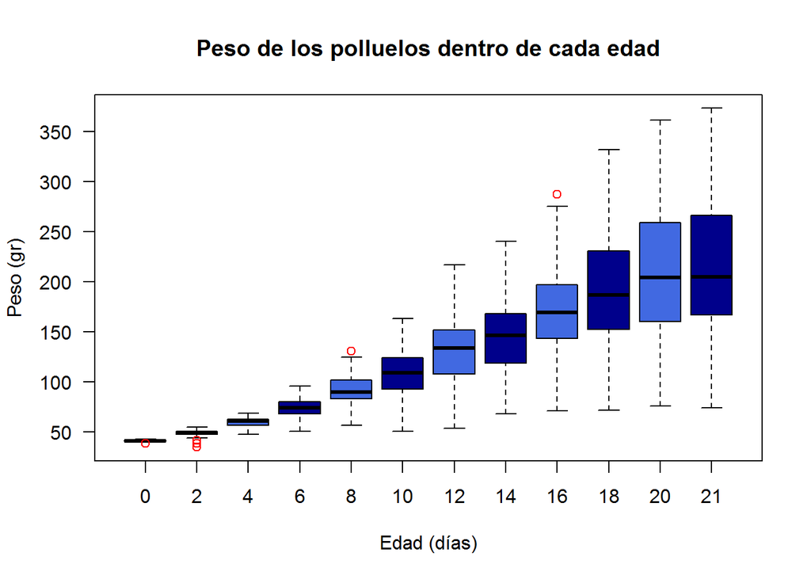

```r
outlier_weight <- boxplot(ChickWeight$weight~ChickWeight$Time,
                          las=1,
                          xlab="Edad (días)",
                          ylab="Peso (gr)",
                          main="Peso de los polluelos dentro de cada edad",
                          col=c("royalblue", "darkblue"),
                          outcol="red")
```

**Resumen de la información**

Valores outlier de peso (gr) que sobrepasan los límites

```r
outlier_weight$out
```

```
##  [1]  39  39  39  39  39  39  39  39  42  35 131 287
```

Grupo al que pertenece cada uno de los valores outlier anteriores

```r
outlier_weight$group
```

```
##  [1] 1 1 1 1 1 1 1 2 2 2 5 9
```

Edad (días) al que se refiere cada uno de los grupos anteriores

```r
outlier_weight$names
```

```
##  [1] "0"  "2"  "4"  "6"  "8"  "10" "12" "14" "16" "18" "20" "21"
```

Existen outlier para 4 grupos de edad 0, 2, 8 y 16 días. Representaremos a continuación el gráfico boxplot para cada uno de estos 4 grupos.

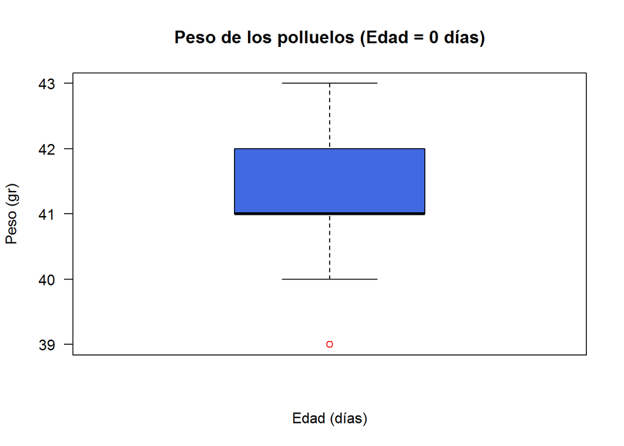

```r
outlier_data0<-subset(ChickWeight, ChickWeight$Time %in% c(0))
outlier0<-boxplot(outlier_data0$weight~outlier_data0$Time,
        las=1,
        xlab="Edad (días)",
        ylab="Peso (gr)",
        main="Peso de los polluelos (Edad = 0 días)",
        col=c("royalblue", "darkblue"),
        outcol="red")
```

```r
outlier0$out
```

```
## [1] 39 39 39 39 39 39 39
```

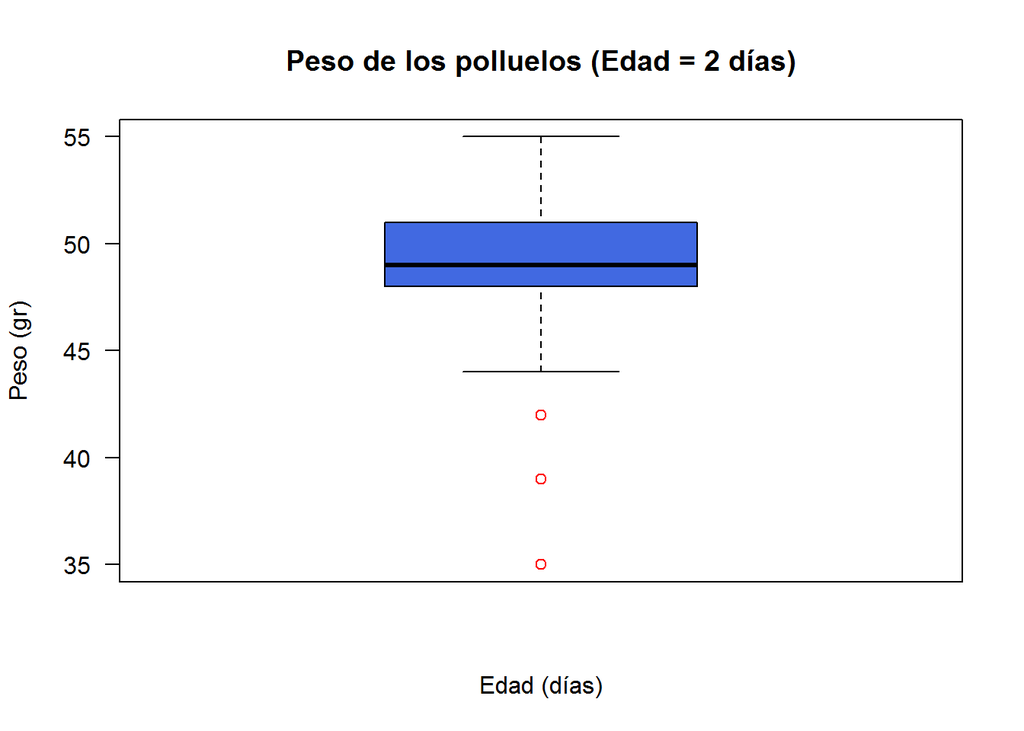

```r
outlier_data2<-subset(ChickWeight, ChickWeight$Time %in% c(2))
outlier2<-boxplot(outlier_data2$weight~outlier_data2$Time,
        las=1,
        xlab="Edad (días)",
        ylab="Peso (gr)",
        main="Peso de los polluelos (Edad = 2 días)",
        col=c("royalblue", "darkblue"),
        outcol="red")
```

```r
outlier2$out
```

```
## [1] 39 42 35
```

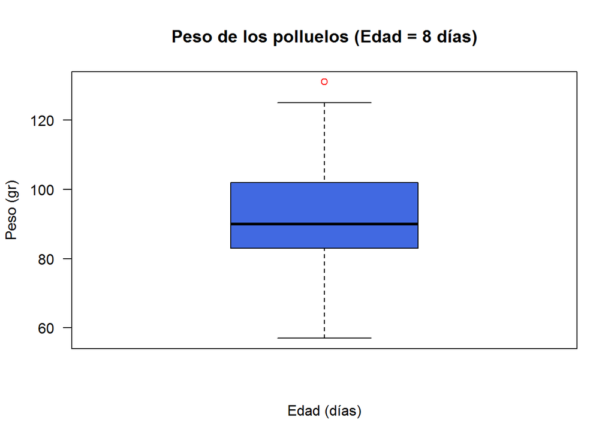

```r
outlier_data8<-subset(ChickWeight, ChickWeight$Time %in% c(8))
outlier8<-boxplot(outlier_data8$weight~outlier_data8$Time,
        las=1,
        xlab="Edad (días)",
        ylab="Peso (gr)",
        main="Peso de los polluelos (Edad = 8 días)",
        col=c("royalblue", "darkblue"),
        outcol="red")
```

```r
outlier8$out
```

```
## [1] 131
```

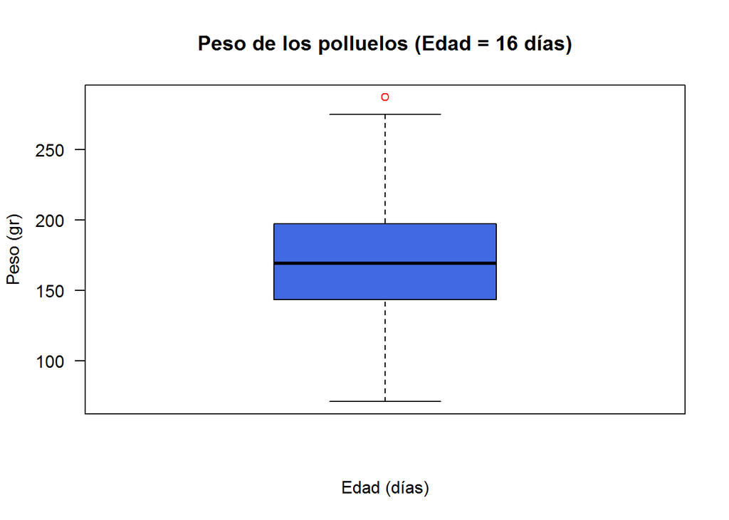

```r
outlier_data16<-subset(ChickWeight, ChickWeight$Time %in% c(16))
outlier16<-boxplot(outlier_data16$weight~outlier_data16$Time,
        las=1,
        xlab="Edad (días)",
        ylab="Peso (gr)",
        main="Peso de los polluelos (Edad = 16 días)",
        col=c("royalblue", "darkblue"),
        outcol="red")
```

```r
outlier16$out
```

```
## [1] 287
```

**3. Calcular la tabla de frecuencias conjuntas (absolutas y marginales) del número de datos de cada polluelo en cada dieta. Añadir las frecuencias marginales.**

Frecuencia conjunta absoluta

```r
FrecAbs_c_d <- table(ChickWeight$Chick, ChickWeight$Diet)
print(knitr::kable(FrecAbs_c_d, format = "pandoc", align='c',
                   caption="Tabla Frecuencias absolutas polluelos en cada dieta"))
```

```
##
##
## Table: Tabla Frecuencias absolutas polluelos en cada dieta
##
##       1     2     3     4
## ---  ----  ----  ----  ----
## 18    2     0     0     0
## 16    7     0     0     0
## 15    8     0     0     0
## 13    12    0     0     0
## 9     12    0     0     0
## 20    12    0     0     0
## 10    12    0     0     0
## 8     11    0     0     0
## 17    12    0     0     0
```

[output cut: 41 more lines]

Frecuencia marginal conjunta sumando por filas

```r
Marginal.X=margin.table(FrecAbs_c_d,margin=1)
print(knitr::kable(as.data.frame(Marginal.X), format = "markdown",
                   col.names = c("Polluelo","Frec. marginal"),align='c'))
```

```
##
##
## | Polluelo | Frec. marginal |
## |:--------:|:--------------:|
## |    18    |       2        |
## |    16    |       7        |
## |    15    |       8        |
## |    13    |       12       |
## |    9     |       12       |
## |    20    |       12       |
## |    10    |       12       |
## |    8     |       11       |
## |    17    |       12       |
## |    19    |       12       |
## |    4     |       12       |
## |    6     |       12       |
## |    11    |       12       |
## |    3     |       12       |
## |    1     |       12       |
## |    12    |       12       |
## |    2     |       12       |
## |    5     |       12       |
## |    14    |       12       |
## |    7     |       12       |
## |    24    |       12       |
## |    30    |       12       |
## |    22    |       12       |
## |    23    |       12       |
## |    27    |       12       |
## |    28    |       12       |
## |    26    |       12       |
## |    25    |       12       |
## |    29    |       12       |
## |    21    |       12       |
## |    33    |       12       |
## |    37    |       12       |
## |    36    |       12       |
## |    31    |       12       |
## |    39    |       12       |
## |    38    |       12       |
## |    32    |       12       |
## |    40    |       12       |
## |    34    |       12       |
## |    35    |       12       |
## |    44    |       10       |
## |    45    |       12       |
## |    43    |       12       |
## |    41    |       12       |
## |    47    |       12       |
## |    49    |       12       |
## |    46    |       12       |
## |    50    |       12       |
## |    42    |       12       |
## |    48    |       12       |
```

Frecuencia marginal conjunta sumando por columnas

```r
Marginal.Y=margin.table(FrecAbs_c_d,margin=2)
print(knitr::kable(as.data.frame(Marginal.Y), format = "markdown",
                   col.names = c("Dieta","Frec. marginal"),align='c'))
```

```
##
##
## | Dieta | Frec. marginal |
## |:-----:|:--------------:|
## |   1   |      220       |
## |   2   |      120       |
## |   3   |      120       |
## |   4   |      118       |
```

Añadimos las distribuciones marginales en el cálculo de las tablas conjuntas

```r
tabla <- addmargins(prop.table(FrecAbs_c_d)*100)
# Modificación de etiquetas, sustituyendo la palabra Sum.
colnames(tabla)[5] = "Marg_Dieta"
rownames(tabla)[51] = "Marg_Polluelo"
round(tabla,3)
```

```
##
##                       1       2       3       4 Marg_Dieta
##   18              0.346   0.000   0.000   0.000      0.346
##   16              1.211   0.000   0.000   0.000      1.211
##   15              1.384   0.000   0.000   0.000      1.384
##   13              2.076   0.000   0.000   0.000      2.076
##   9               2.076   0.000   0.000   0.000      2.076
##   20              2.076   0.000   0.000   0.000      2.076
##   10              2.076   0.000   0.000   0.000      2.076
##   8               1.903   0.000   0.000   0.000      1.903
##   17              2.076   0.000   0.000   0.000      2.076
##   19              2.076   0.000   0.000   0.000      2.076
##   4               2.076   0.000   0.000   0.000      2.076
##   6               2.076   0.000   0.000   0.000      2.076
##   11              2.076   0.000   0.000   0.000      2.076
```

[output cut: 38 more lines]

**4. Calcular el histograma del peso (6 grupos) en cada grupo de edad.**

Cálculo del peso en cada grupo de edad

```r
peso0<-subset(ChickWeight, Time==0)
peso2<-subset(ChickWeight, Time==2)
peso4<-subset(ChickWeight, Time==4)
peso6<-subset(ChickWeight, Time==6)
peso8<-subset(ChickWeight, Time==8)
peso10<-subset(ChickWeight, Time==10)
peso12<-subset(ChickWeight, Time==12)
peso14<-subset(ChickWeight, Time==14)
peso16<-subset(ChickWeight, Time==16)
peso18<-subset(ChickWeight, Time==18)
peso20<-subset(ChickWeight, Time==20)
peso21<-subset(ChickWeight, Time==21)
```

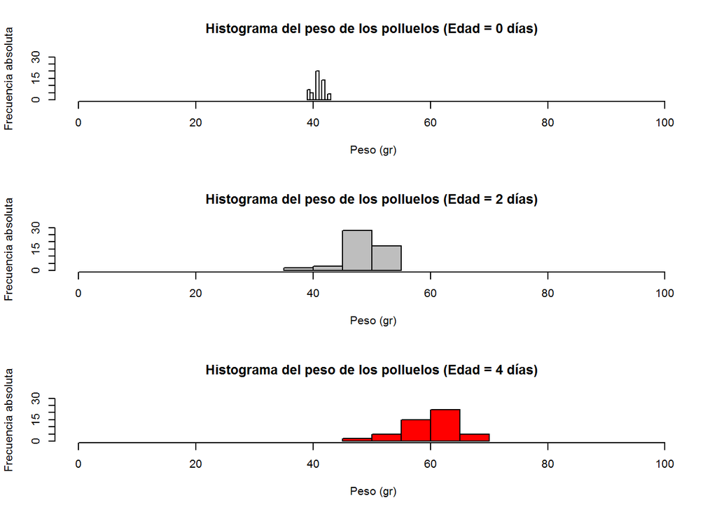

```r
par(mfrow = c(3, 1))

hist(peso0$weight, breaks=7, xlim=c(0,100), ylim=c(0,30), col="white", freq=T, main="Histograma del peso de los polluelos (Edad = 0 días)", xlab=" Peso (gr)", ylab="Frecuencia absoluta")

hist(peso2$weight, breaks=7, xlim=c(0,100), ylim=c(0,30), col="gray", freq=T, main="Histograma del peso de los polluelos (Edad = 2 días)", xlab=" Peso (gr)", ylab="Frecuencia absoluta")

hist(peso4$weight, breaks=7, xlim=c(0,100), ylim=c(0,30), col="red", freq=T, main="Histograma del peso de los polluelos (Edad = 4 días)", xlab=" Peso (gr)", ylab="Frecuencia absoluta")
```

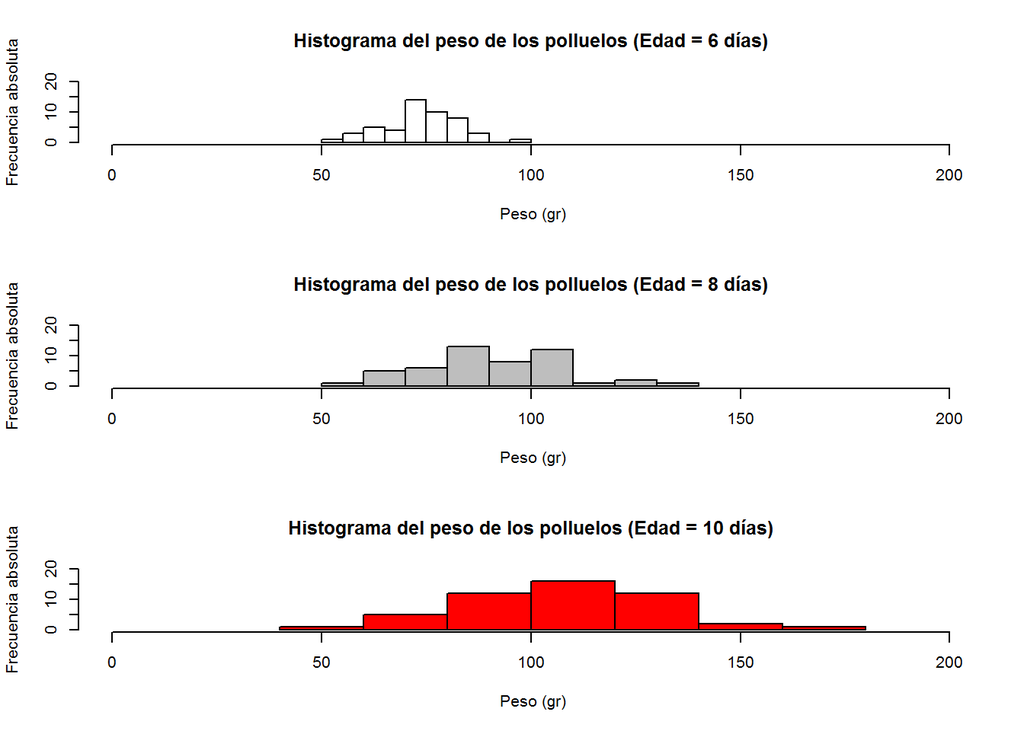

```r
hist(peso6$weight, breaks=7, xlim=c(0,200), ylim=c(0,20), col="white", freq=T, main="Histograma del peso de los polluelos (Edad = 6 días)", xlab=" Peso (gr)", ylab="Frecuencia absoluta")

hist(peso8$weight, breaks=7, xlim=c(0,200), ylim=c(0,20), col="gray", freq=T, main="Histograma del peso de los polluelos (Edad = 8 días)", xlab=" Peso (gr)", ylab="Frecuencia absoluta")

hist(peso10$weight, breaks=7, xlim=c(0,200), ylim=c(0,20), col="red", freq=T, main="Histograma del peso de los polluelos (Edad = 10 días)", xlab=" Peso (gr)", ylab="Frecuencia absoluta")
```

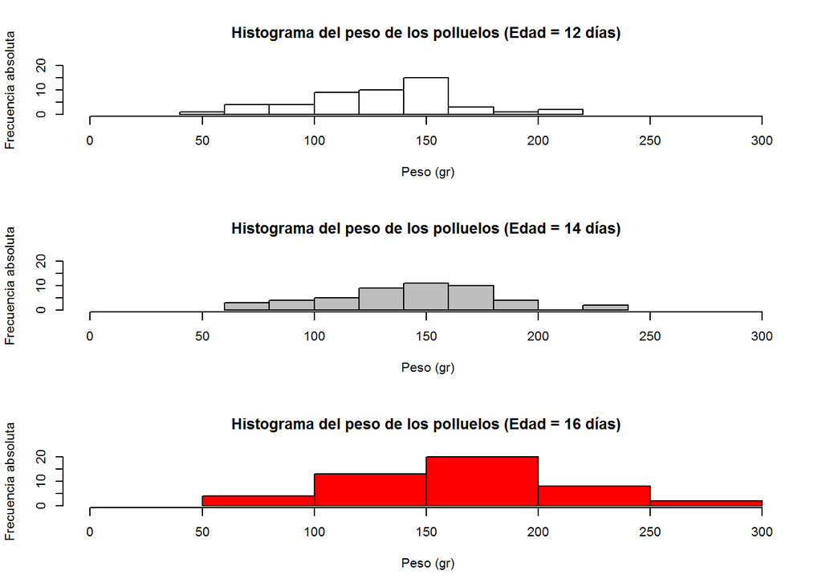

```r
hist(peso12$weight, breaks=7, xlim=c(0,300), ylim=c(0,20), col="white", freq=T, main="Histograma del peso de los polluelos (Edad = 12 días)", xlab=" Peso (gr)", ylab="Frecuencia absoluta")

hist(peso14$weight, breaks=7, xlim=c(0,300), ylim=c(0,20), col="grey", freq=T, main="Histograma del peso de los polluelos (Edad = 14 días)", xlab=" Peso (gr)", ylab="Frecuencia absoluta")

hist(peso16$weight, breaks=7, xlim=c(0,300), ylim=c(0,20), col="red", freq=T, main="Histograma del peso de los polluelos (Edad = 16 días)", xlab=" Peso (gr)", ylab="Frecuencia absoluta")
```

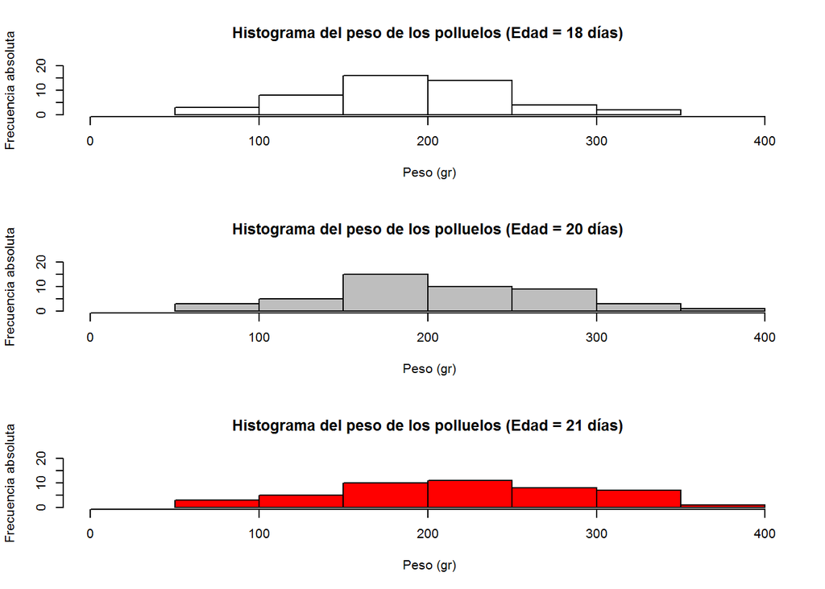

```r
hist(peso18$weight, breaks=7, xlim=c(0,400), ylim=c(0,20), col="white", freq=T, main="Histograma del peso de los polluelos (Edad = 18 días)", xlab=" Peso (gr)", ylab="Frecuencia absoluta")

hist(peso20$weight, breaks=7, xlim=c(0,400), ylim=c(0,20), col="grey", freq=T, main="Histograma del peso de los polluelos (Edad = 20 días)", xlab=" Peso (gr)", ylab="Frecuencia absoluta")

hist(peso21$weight, breaks=7, xlim=c(0,400), ylim=c(0,20), col="red", freq=T, main="Histograma del peso de los polluelos (Edad = 21 días)", xlab=" Peso (gr)", ylab="Frecuencia absoluta")
```

**Ejemplo 2.- Considerar el conjunto de datos trees de R (data(trees)), que contiene la circunferencia, altura y volumen de cerezos.**

```r
#?trees
names(trees)
```

```
## [1] "Girth"  "Height" "Volume"
```

```r
str(trees)
```

```
## 'data.frame':    31 obs. of  3 variables:
##  $ Girth : num  8.3 8.6 8.8 10.5 10.7 10.8 11 11 11.1 11.2 ...
##  $ Height: num  70 65 63 72 81 83 66 75 80 75 ...
##  $ Volume: num  10.3 10.3 10.2 16.4 18.8 19.7 15.6 18.2 22.6 19.9 ...
```

```r
head(trees)
```

```
##   Girth Height Volume
## 1   8.3     70   10.3
## 2   8.6     65   10.3
## 3   8.8     63   10.2
## 4  10.5     72   16.4
## 5  10.7     81   18.8
## 6  10.8     83   19.7
```

**1. Dividir las alturas en tres grupos y realizar un histograma de las restantes variables en cada grupo definido**

```r
FrecAbs_height <- table(trees$Height)
FrecAbs_height
```

```
##
## 63 64 65 66 69 70 71 72 74 75 76 77 78 79 80 81 82 83 85 86 87
##  1  1  1  1  1  1  1  2  2  3  2  1  1  1  5  2  1  1  1  1  1
```

Dividiremos las alturas en los siguientes grupos:

Grupo 1: [60, 70)

Grupo 2: [70, 80)

Grupo 3: [80, 90)

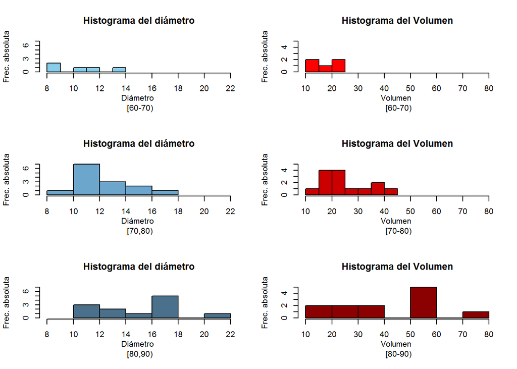

```r
height1<-subset(trees, trees$Height>=60 & trees$Height<70)
height2<-subset(trees, trees$Height>=70 & trees$Height<80)
height3<-subset(trees, trees$Height>=80 & trees$Height<90)

par(mfrow = c(3, 2))

hist(height1$Girth, xlim=c(8,22), ylim=c(0,7), col="skyblue",main="Histograma del diámetro", xlab="Diámetro \n [60-70)", ylab="Frec. absoluta")

hist(height1$Volume, xlim=c(10,80), ylim=c(0,5), col="red", main="Histograma del Volumen", xlab="Volumen \n [60-70)", ylab="Frec. absoluta")


hist(height2$Girth, xlim=c(8,22), ylim=c(0,7), col="skyblue3", main="Histograma del diámetro", xlab="Diámetro \n [70,80)", ylab="Frec. absoluta")

hist(height2$Volume, xlim=c(10,80), ylim=c(0,5), col="red3", main="Histograma del Volumen", xlab="Volumen \n [70-80)", ylab="Frec. absoluta")


hist(height3$Girth, xlim=c(8,22), ylim=c(0,7), col="skyblue4", main="Histograma del diámetro", xlab="Diámetro \n [80,90)", ylab="Frec. absoluta")

hist(height3$Volume, xlim=c(10,80), ylim=c(0,5), col="red4", main="Histograma del Volumen", xlab="Volumen \n [80-90)", ylab="Frec. absoluta")
```

**2. Realizar un diagrama de dispersión de la circunferencia frente al volumen diferenciando los grupos definidos por la altura.**

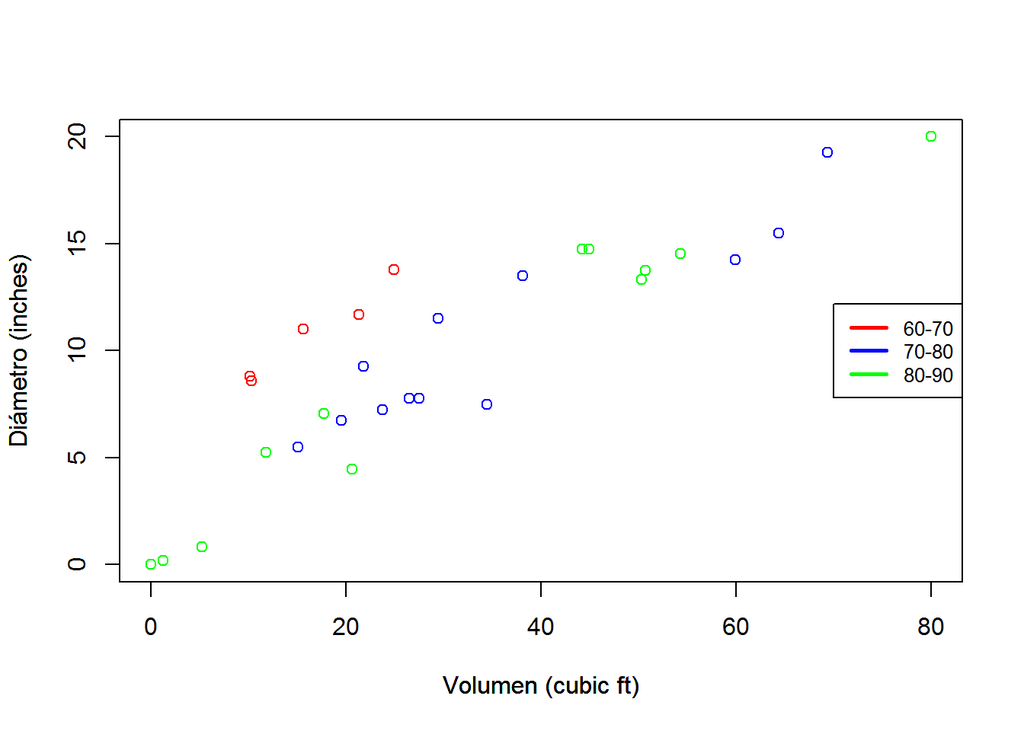

```r
library(ggplot2)


plot(height1$Volume, height1$Girth, col="red", xlim=c(0,80), ylim=c(0,20), xlab="Volumen (cubic ft)", ylab="Diámetro (inches)")

par(mfrow=c(1,1), new=TRUE)
plot(height2$Volume, height2$Girth, col="blue", axes=FALSE, xlab="Volumen (cubic ft)", ylab="Diámetro (inches)")

par(mfrow=c(1,1), new=TRUE)
plot(height3$Volume, height3$Girth, col="green", axes=FALSE, xlab="Volumen (cubic ft)", ylab="Diámetro (inches)")

par(mfrow=c(1,1), new=TRUE)
legend("right", legend=c("60-70", "70-80", "80-90"),
       col=c("red", "blue", "green"), lty=c(1, 1, 1),
       lwd=c(2.5, 2.5, 2.5), cex=0.8)
```

**3. Realizar un gráfico de dispersión y una regresión de cada par de variables y valorar la relación existente entre ellas.**

**Grirth - Height**

```r
X <- trees$Girth
Y <- trees$Height

modelo = lm(Y~X)
summary(modelo)
```

```
##
## Call:
## lm(formula = Y ~ X)
##
## Residuals:
##      Min       1Q   Median       3Q      Max
## -12.5816  -2.7686   0.3163   2.4728   9.9456
##
## Coefficients:
##             Estimate Std. Error t value Pr(>|t|)
## (Intercept)  62.0313     4.3833  14.152 1.49e-14 ***
## X             1.0544     0.3222   3.272  0.00276 **
## ---
## Signif. codes:  0 '***' 0.001 '**' 0.01 '*' 0.05 '.' 0.1 ' ' 1
##
## Residual standard error: 5.538 on 29 degrees of freedom
## Multiple R-squared:  0.2697, Adjusted R-squared:  0.2445
## F-statistic: 10.71 on 1 and 29 DF,  p-value: 0.002758
```

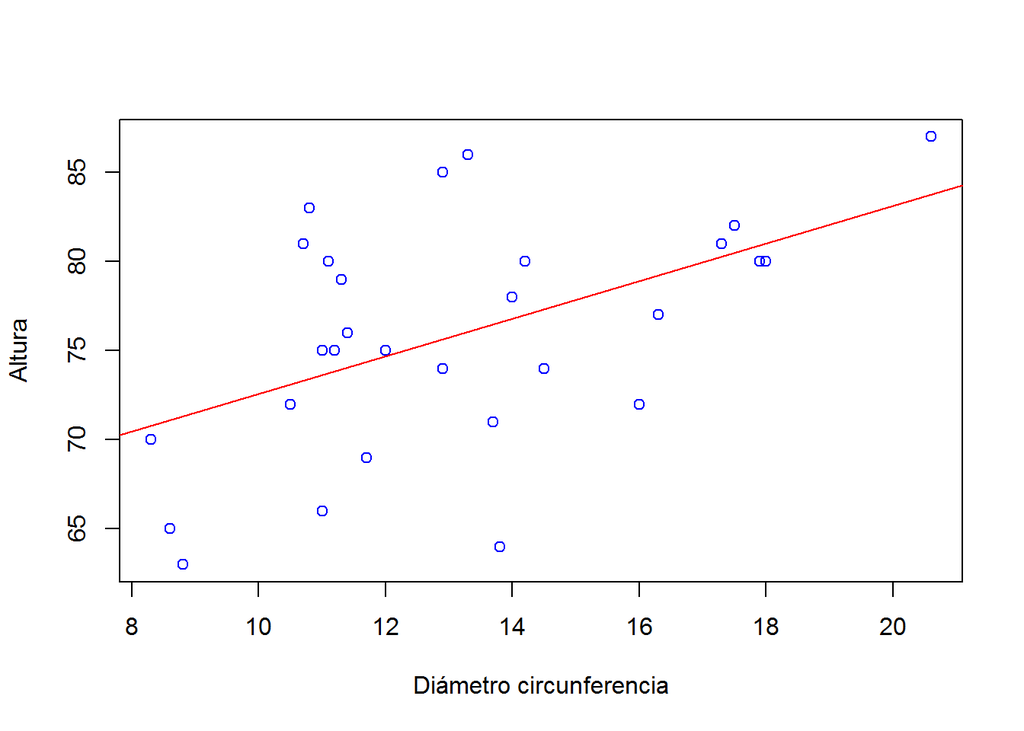

```r
# Gráfico de dispersión
plot(X,Y, col="blue", xlab="Diámetro circunferencia", ylab="Altura")

# Línea de regresión
abline(modelo, col="red")
```

Valoración:

- Coeficiente de determinación (Multiple R-squared) =0.2697 < 1
- Los datos no se ajustan bien a la recta de regresión lineal (R no está proximo a 1)
- No se puede modelar la relación entre las variables Grirth - Height como una recta

**Grirth - Volume**

```r
X <- trees$Girth
Y <- trees$Volume

modelo = lm(Y~X)
summary(modelo)
```

```
##
## Call:
## lm(formula = Y ~ X)
##
## Residuals:
##    Min     1Q Median     3Q    Max
## -8.065 -3.107  0.152  3.495  9.587
##
## Coefficients:
##             Estimate Std. Error t value Pr(>|t|)
## (Intercept) -36.9435     3.3651  -10.98 7.62e-12 ***
## X             5.0659     0.2474   20.48  < 2e-16 ***
## ---
## Signif. codes:  0 '***' 0.001 '**' 0.01 '*' 0.05 '.' 0.1 ' ' 1
##
## Residual standard error: 4.252 on 29 degrees of freedom
## Multiple R-squared:  0.9353, Adjusted R-squared:  0.9331
## F-statistic: 419.4 on 1 and 29 DF,  p-value: < 2.2e-16
```

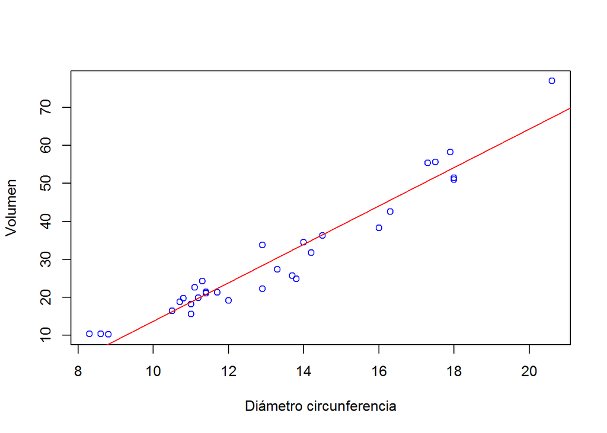

```r
# Gráfico de dispersión
plot(X,Y, col="blue", xlab="Diámetro circunferencia", ylab="Volumen")

# Línea de regresión
abline(modelo, col="red")
```

Valoración:

- Coeficiente de determinación (Multiple R-squared) =0.9353 ~ 1
- Los datos se ajustan bien a la recta de regresión lineal (R~1)
- Se puede modelar la relación entre las variables Grirth - Volume como una recta
- La resta de ajuste es la siguiente: Volume = -36.9435 + 5.0659 Girth

**Height - Volume**

```r
X <- trees$Height
Y <- trees$Volume

modelo = lm(Y~X)
summary(modelo)
```

```
##
## Call:
## lm(formula = Y ~ X)
##
## Residuals:
##     Min      1Q  Median      3Q     Max
## -21.274  -9.894  -2.894  12.068  29.852
##
## Coefficients:
##             Estimate Std. Error t value Pr(>|t|)
## (Intercept) -87.1236    29.2731  -2.976 0.005835 **
## X             1.5433     0.3839   4.021 0.000378 ***
## ---
## Signif. codes:  0 '***' 0.001 '**' 0.01 '*' 0.05 '.' 0.1 ' ' 1
##
## Residual standard error: 13.4 on 29 degrees of freedom
## Multiple R-squared:  0.3579, Adjusted R-squared:  0.3358
## F-statistic: 16.16 on 1 and 29 DF,  p-value: 0.0003784
```

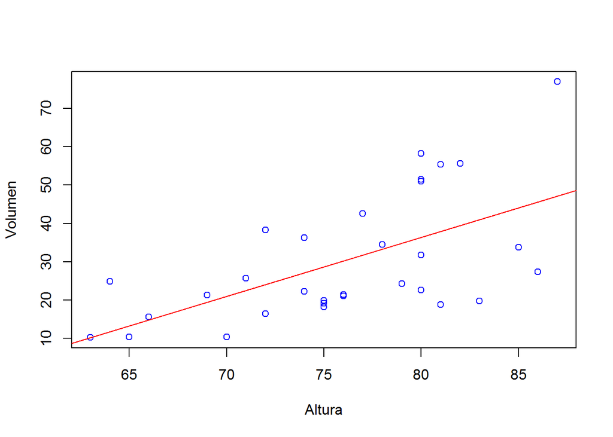

```r
# Gráfico de dispersión
plot(X,Y, col="blue", xlab="Altura", ylab="Volumen")

# Línea de regresión
abline(modelo, col="red")
```

Valoración:

- Coeficiente de determinación (Multiple R-squared) =0.3579 < 1
- Los datos no se ajustan bien a la recta de regresión lineal (R no está proximo a 1)
- No se puede modelar la relación entre las variables Height - Volume como una recta

**Ejemplo 3.- Seleccionar un fichero de datos adecuado en R para aplicar cada uno de los siguientes análisis:**

Elijo el dataset “attenu” (The Joyner-Boore Attenuation Data)

Lectura y preparación de los datos

```r
#?attenu
names(attenu)
```

```
## [1] "event"   "mag"     "station" "dist"    "accel"
```

```r
str(attenu)
```

```
## 'data.frame':    182 obs. of  5 variables:
##  $ event  : num  1 2 2 2 2 2 2 2 2 2 ...
##  $ mag    : num  7 7.4 7.4 7.4 7.4 7.4 7.4 7.4 7.4 7.4 ...
##  $ station: Factor w/ 117 levels "1008","1011",..: 24 13 15 68 39 74 22 1 8 55 ...
##  $ dist   : num  12 148 42 85 107 109 156 224 293 359 ...
##  $ accel  : num  0.359 0.014 0.196 0.135 0.062 0.054 0.014 0.018 0.01 0.004 ...
```

```r
head(attenu)
```

```
##   event mag station dist accel
## 1     1 7.0     117   12 0.359
## 2     2 7.4    1083  148 0.014
## 3     2 7.4    1095   42 0.196
## 4     2 7.4     283   85 0.135
## 5     2 7.4     135  107 0.062
## 6     2 7.4     475  109 0.054
```

**1. Calcular la tabla de frecuencias absolutas de al menos dos variables. Obtener una tabla formateada para latex con ayuda del paquete knitr**

Tabla de frecuencias absoluta variable Magnitud (mag)

```r
FrecAbs_mag <- table(attenu$mag)
print(knitr::kable(as.data.frame(FrecAbs_mag), format = "latex",
                   col.names = c("Magnitud","Frec. absoluta"),align='c',
                   caption="Tabla Frecuencias absolutas Magnitud"))
```

```
## \begin{table}
##
## \caption{\label{tab:unnamed-chunk-22}Tabla Frecuencias absolutas Magnitud}
## \centering
## \begin{tabular}[t]{c|c}
## \hline
## Magnitud & Frec. absoluta\\
## \hline
## 5 & 16\\
## \hline
## 5.1 & 3\\
## \hline
## 5.2 & 4\\
## \hline
## 5.3 & 25\\
## \hline
## 5.5 & 10\\
## \hline
## 5.6 & 3\\
## \hline
## 5.7 & 1\\
## \hline
## 5.8 & 18\\
## \hline
## 6 & 4\\
## \hline
## 6.1 & 9\\
## \hline
## 6.2 & 1\\
## \hline
## 6.5 & 38\\
## \hline
## 6.6 & 33\\
## \hline
## 7 & 1\\
## \hline
## 7.4 & 10\\
## \hline
## 7.6 & 3\\
## \hline
## 7.7 & 3\\
## \hline
## \end{tabular}
## \end{table}
```

Tabla de frecuencias absoluta variable Aceleracion (accel)

```r
FrecAbs_accel <- table(attenu$accel)
print(knitr::kable(as.data.frame(FrecAbs_accel), format = "latex",
                   col.names = c("Aceleracion (g)","Frec. absoluta"),align='c',
                   caption="Tabla Frecuencias absolutas Aceleracion"))
```

```
## \begin{table}
##
## \caption{\label{tab:unnamed-chunk-23}Tabla Frecuencias absolutas Aceleracion}
## \centering
## \begin{tabular}[t]{c|c}
## \hline
## Aceleracion (g) & Frec. absoluta\\
## \hline
## 0.003 & 2\\
## \hline
## 0.004 & 2\\
## \hline
## 0.005 & 1\\
## \hline
## 0.006 & 3\\
## \hline
## 0.007 & 1\\
## \hline
## 0.01 & 5\\
## \hline
## 0.011 & 2\\
## \hline
## 0.012 & 1\\
## \hline
## 0.013 & 1\\
## \hline
## 0.014 & 2\\
## \hline
## 0.017 & 1\\
## \hline
## 0.018 & 3\\
## \hline
## 0.021 & 1\\
## \hline
## 0.022 & 2\\
## \hline
## 0.026 & 2\\
## \hline
## 0.027 & 1\\
## \hline
```

[output cut: 195 more lines]

```
## \hline
## 0.52 & 1\\
## \hline
## 0.56 & 1\\
## \hline
## 0.61 & 1\\
## \hline
## 0.64 & 1\\
## \hline
## 0.72 & 1\\
## \hline
## 0.81 & 1\\
## \hline
## \end{tabular}
## \end{table}
```

Tabla de frecuencias absoluta variable Distancia hipocentro (dist)

```r
FrecAbs_dist <- table(attenu$dist)
print(knitr::kable(as.data.frame(FrecAbs_dist), format = "latex",
                   col.names = c("Distancia (km)","Frec. absoluta"),align='c',
                   caption="Tabla Frecuencias absolutas Distancia"))
```

```
## \begin{table}
##
## \caption{\label{tab:unnamed-chunk-24}Tabla Frecuencias absolutas Distancia}
## \centering
## \begin{tabular}[t]{c|c}
## \hline
## Distancia (km) & Frec. absoluta\\
## \hline
## 0.5 & 1\\
## \hline
## 0.6 & 1\\
## \hline
## 1.2 & 1\\
## \hline
## 1.3 & 1\\
## \hline
## 1.4 & 1\\
## \hline
## 1.6 & 1\\
## \hline
## 2.6 & 1\\
## \hline
## 2.9 & 1\\
## \hline
## 3.2 & 1\\
## \hline
## 3.7 & 1\\
## \hline
## 3.8 & 1\\
## \hline
## 4 & 2\\
## \hline
## 5 & 1\\
## \hline
## 5.1 & 1\\
## \hline
## 5.3 & 1\\
## \hline
## 5.8 & 1\\
## \hline
```

[output cut: 261 more lines]

```
## \hline
## 211 & 1\\
## \hline
## 224 & 1\\
## \hline
## 293 & 1\\
## \hline
## 300 & 1\\
## \hline
## 359 & 1\\
## \hline
## 370 & 1\\
## \hline
## \end{tabular}
## \end{table}
```

**2. Calcular la tabla de frecuencias (absolutas, relativas y acumuladas) formateada para latex para al menos dos variables.**

**Tabla de frecuencias para la variable Distancia hipocentro (dist)**

```r
# Tabla de frecuencias absolutas
FrecAbs_dist <- round(table(attenu$dist),3)

# Tabla de frecuencias relativas
FrecRel_dist<-round(prop.table(FrecAbs_dist),3)

# Tabla de frecuencias absolutas acumuladas
FrecAbsAcum_dist <- round(cumsum(FrecAbs_dist),3)

# Tabla de frecuencias relativas acumuladas
FrecRelAcum_dist <- round(cumsum(FrecRel_dist),3)

tabla_dist=cbind(FrecAbs_dist, FrecRel_dist, FrecAbsAcum_dist, FrecRelAcum_dist)

print(knitr::kable(tabla_dist,
                   format = "latex",
                   col.names = c("Frec. Absolutas","Frec. Relativas", "Frec. Absol acum", "Frec. Rel. Acum"),
                   align='c',
                   caption="Tabla Frecuencias Distancia"))
```

```
## \begin{table}
##
## \caption{\label{tab:unnamed-chunk-25}Tabla Frecuencias Distancia}
## \centering
## \begin{tabular}[t]{l|c|c|c|c}
## \hline
##   & Frec. Absolutas & Frec. Relativas & Frec. Absol acum & Frec. Rel. Acum\\
## \hline
## 0.5 & 1 & 0.005 & 1 & 0.005\\
## \hline
## 0.6 & 1 & 0.005 & 2 & 0.010\\
## \hline
## 1.2 & 1 & 0.005 & 3 & 0.015\\
## \hline
## 1.3 & 1 & 0.005 & 4 & 0.020\\
## \hline
## 1.4 & 1 & 0.005 & 5 & 0.025\\
## \hline
## 1.6 & 1 & 0.005 & 6 & 0.030\\
## \hline
## 2.6 & 1 & 0.005 & 7 & 0.035\\
## \hline
## 2.9 & 1 & 0.005 & 8 & 0.040\\
## \hline
## 3.2 & 1 & 0.005 & 9 & 0.045\\
## \hline
## 3.7 & 1 & 0.005 & 10 & 0.050\\
## \hline
## 3.8 & 1 & 0.005 & 11 & 0.055\\
## \hline
## 4 & 2 & 0.011 & 13 & 0.066\\
## \hline
## 5 & 1 & 0.005 & 14 & 0.071\\
## \hline
## 5.1 & 1 & 0.005 & 15 & 0.076\\
## \hline
## 5.3 & 1 & 0.005 & 16 & 0.081\\
## \hline
## 5.8 & 1 & 0.005 & 17 & 0.086\\
## \hline
```

[output cut: 261 more lines]

```
## \hline
## 211 & 1 & 0.005 & 177 & 0.909\\
## \hline
## 224 & 1 & 0.005 & 178 & 0.914\\
## \hline
## 293 & 1 & 0.005 & 179 & 0.919\\
## \hline
## 300 & 1 & 0.005 & 180 & 0.924\\
## \hline
## 359 & 1 & 0.005 & 181 & 0.929\\
## \hline
## 370 & 1 & 0.005 & 182 & 0.934\\
## \hline
## \end{tabular}
## \end{table}
```

**Tabla de frecuencias de la Variable Aceleración (accel)**

```r
# Tabla de frecuencias absolutas
FrecAbs_accel <- round(table(attenu$accel),3)

# Tabla de frecuencias relativas
FrecRel_accel <-round(prop.table(FrecAbs_accel),3)

# Tabla de frecuencias absolutas acumuladas
FrecAbsAcum_accel <- round(cumsum(FrecAbs_accel),3)

# Tabla de frecuencias relativas acumuladas
FrecRelAcum_accel <- round(cumsum(FrecRel_accel),3)

tabla_accel=cbind(FrecAbs_accel, FrecRel_accel, FrecAbsAcum_accel, FrecRelAcum_accel)

print(knitr::kable(tabla_accel,
                   format = "latex",
                   col.names = c("Frec. Absolutas","Frec. Relativas", "Frec. Absol acum", "Frec. Rel. Acum"),
                   align='c',
                   caption="Tabla Frecuencias Aceleración"))
```

```
## \begin{table}
##
## \caption{\label{tab:unnamed-chunk-26}Tabla Frecuencias Aceleración}
## \centering
## \begin{tabular}[t]{l|c|c|c|c}
## \hline
##   & Frec. Absolutas & Frec. Relativas & Frec. Absol acum & Frec. Rel. Acum\\
## \hline
## 0.003 & 2 & 0.011 & 2 & 0.011\\
## \hline
## 0.004 & 2 & 0.011 & 4 & 0.022\\
## \hline
## 0.005 & 1 & 0.005 & 5 & 0.027\\
## \hline
## 0.006 & 3 & 0.016 & 8 & 0.043\\
## \hline
## 0.007 & 1 & 0.005 & 9 & 0.048\\
## \hline
## 0.01 & 5 & 0.027 & 14 & 0.075\\
## \hline
## 0.011 & 2 & 0.011 & 16 & 0.086\\
## \hline
## 0.012 & 1 & 0.005 & 17 & 0.091\\
## \hline
## 0.013 & 1 & 0.005 & 18 & 0.096\\
## \hline
## 0.014 & 2 & 0.011 & 20 & 0.107\\
## \hline
## 0.017 & 1 & 0.005 & 21 & 0.112\\
## \hline
## 0.018 & 3 & 0.016 & 24 & 0.128\\
## \hline
## 0.021 & 1 & 0.005 & 25 & 0.133\\
## \hline
## 0.022 & 2 & 0.011 & 27 & 0.144\\
## \hline
## 0.026 & 2 & 0.011 & 29 & 0.155\\
## \hline
## 0.027 & 1 & 0.005 & 30 & 0.160\\
## \hline
```

[output cut: 195 more lines]

```
## \hline
## 0.52 & 1 & 0.005 & 177 & 0.932\\
## \hline
## 0.56 & 1 & 0.005 & 178 & 0.937\\
## \hline
## 0.61 & 1 & 0.005 & 179 & 0.942\\
## \hline
## 0.64 & 1 & 0.005 & 180 & 0.947\\
## \hline
## 0.72 & 1 & 0.005 & 181 & 0.952\\
## \hline
## 0.81 & 1 & 0.005 & 182 & 0.957\\
## \hline
## \end{tabular}
## \end{table}
```

**3. Aplicar al menos a tres variables las funciones de resumen descriptivo.**

```r
summary(attenu)
```

```
##      event            mag           station         dist
##  Min.   : 1.00   Min.   :5.000   117    :  5   Min.   :  0.50
##  1st Qu.: 9.00   1st Qu.:5.300   1028   :  4   1st Qu.: 11.32
##  Median :18.00   Median :6.100   113    :  4   Median : 23.40
##  Mean   :14.74   Mean   :6.084   112    :  3   Mean   : 45.60
##  3rd Qu.:20.00   3rd Qu.:6.600   135    :  3   3rd Qu.: 47.55
##  Max.   :23.00   Max.   :7.700   (Other):147   Max.   :370.00
##                                  NA's   : 16
##      accel
##  Min.   :0.00300
##  1st Qu.:0.04425
##  Median :0.11300
##  Mean   :0.15422
##  3rd Qu.:0.21925
##  Max.   :0.81000
##
```

**4. Estudiar los posibles outliers de las variables que lo permitan (al menos dos variables). Acompañar con la gráficas adecuadas.**

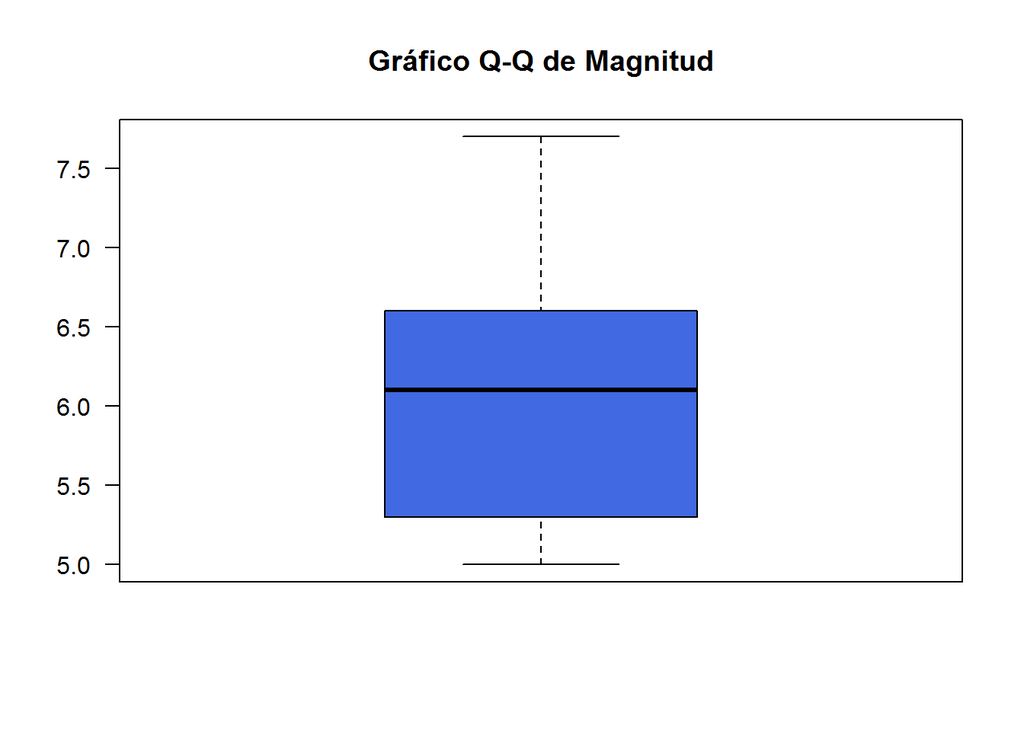

```r
outlier_mag <- boxplot(attenu$mag, las=1, main="Gráfico Q-Q de Magnitud",
                       col="royalblue",
                       outcol="red")
```

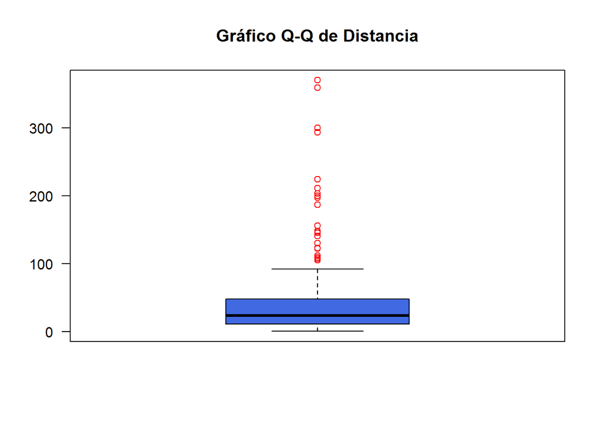

```r
outlier_dist <- boxplot(attenu$dist, las=1, main="Gráfico Q-Q de Distancia",
                       col="royalblue",
                       outcol="red")
```

```r
outlier_dist$out
```

```
##  [1] 148 107 109 156 224 293 359 370 105 112 123 105 122 141 200 130 147
## [18] 187 197 203 211 145 300
```

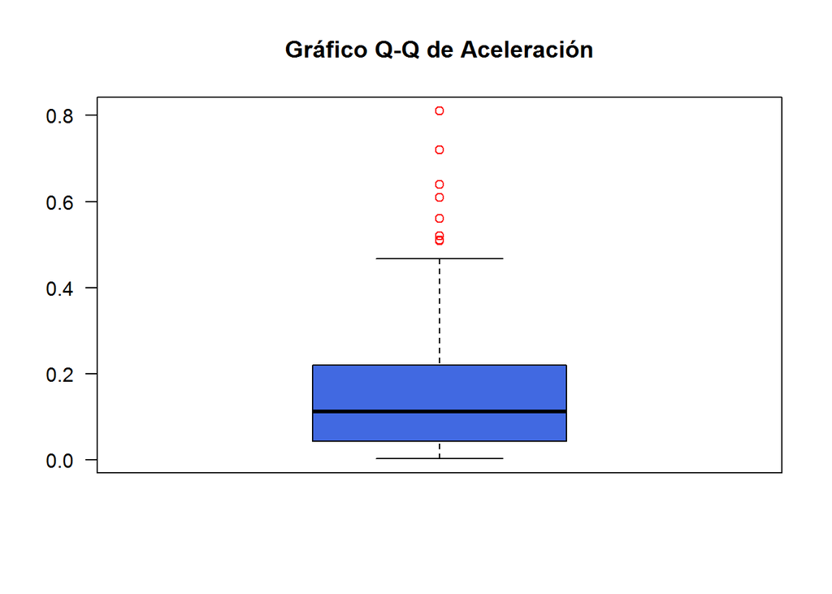

```r
outlier_accel <- boxplot(attenu$accel, las=1, main="Gráfico Q-Q de Aceleración",
                       col="royalblue",
                       outcol="red")
```

```r
outlier_accel$out
```

```
## [1] 0.509 0.520 0.720 0.810 0.640 0.560 0.510 0.610
```

**5. Obtener el histograma de al menos una variable del conjunto de datos.**

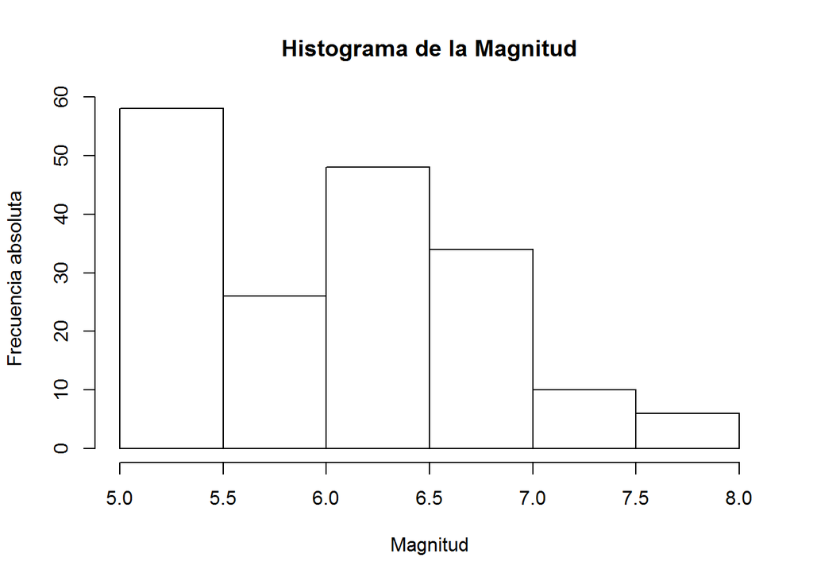

```r
hist(attenu$mag, col="white", freq=T, main="Histograma de la Magnitud", xlab="Magnitud", ylab="Frecuencia absoluta")
```

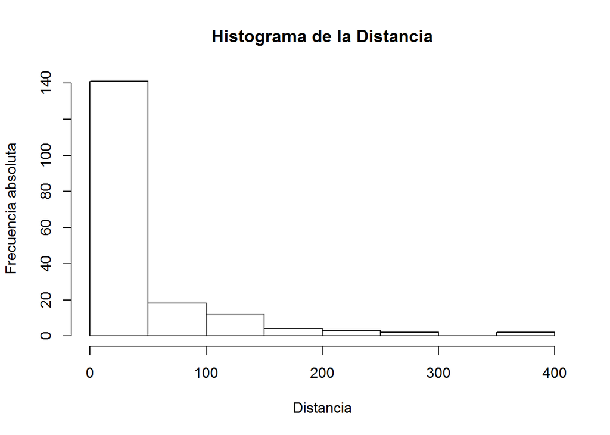

```r
hist(attenu$dist, col="white", freq=T, main="Histograma de la Distancia", xlab="Distancia", ylab="Frecuencia absoluta")
```

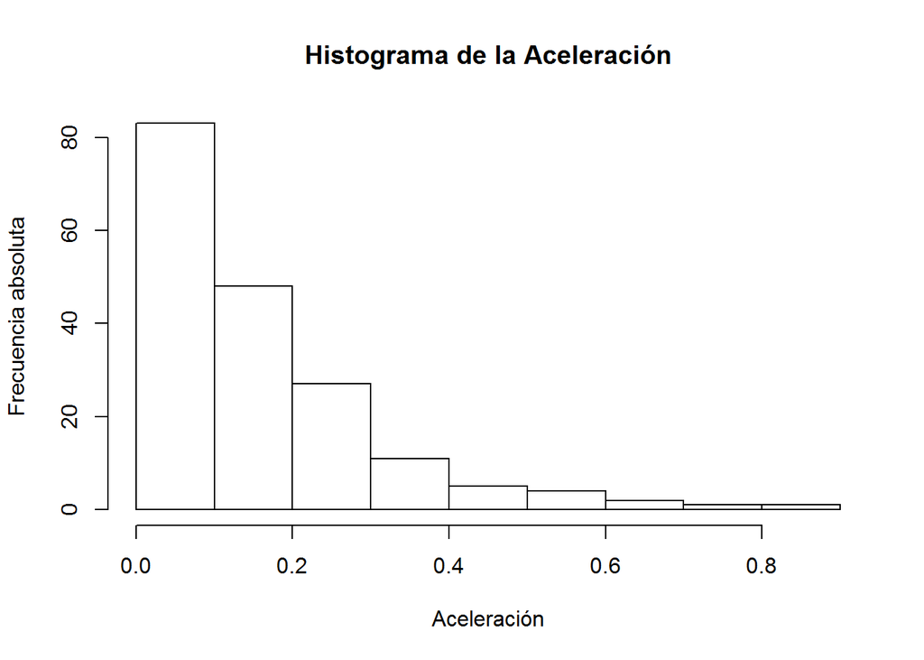

```r
hist(attenu$accel, col="white", freq=T, main="Histograma de la Aceleración", xlab="Aceleración", ylab="Frecuencia absoluta")
```

**6. Seleccionar dos variables que permitan realizar un gráfico de dispersión y un análisis de regresión entre ellas.**

```r
X <- attenu$accel
Y <- attenu$dist

modelo = lm(Y~X)
summary(modelo)
```

```
##
## Call:
## lm(formula = Y ~ X)
##
## Residuals:
##     Min      1Q  Median      3Q     Max
## -56.772 -30.323 -17.465   8.671 294.851
##
## Coefficients:
##             Estimate Std. Error t value Pr(>|t|)
## (Intercept)   75.935      5.874  12.928  < 2e-16 ***
## X           -196.682     27.428  -7.171 1.86e-11 ***
## ---
## Signif. codes:  0 '***' 0.001 '**' 0.01 '*' 0.05 '.' 0.1 ' ' 1
##
## Residual standard error: 54.98 on 180 degrees of freedom
## Multiple R-squared:  0.2222, Adjusted R-squared:  0.2179
## F-statistic: 51.42 on 1 and 180 DF,  p-value: 1.864e-11
```

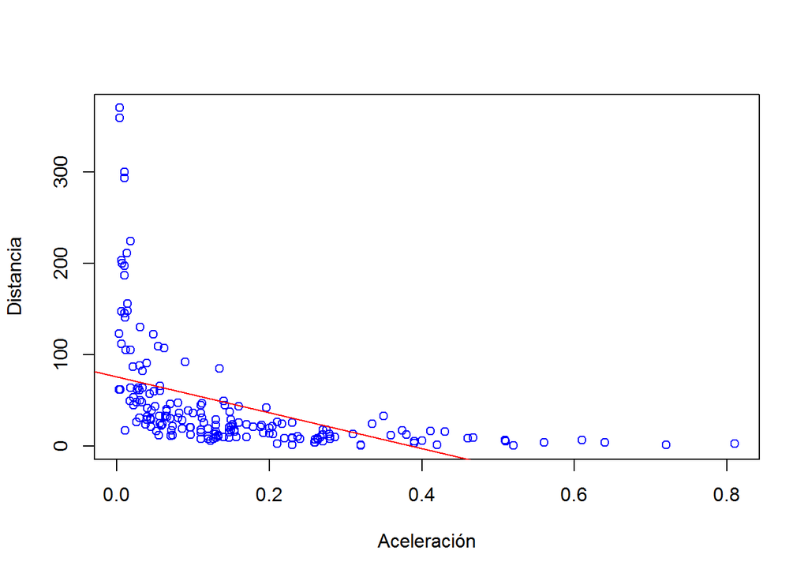

```r
# Gráfico de dispersión
plot(X,Y, col="blue", xlab="Aceleración", ylab="Distancia")

# Línea de regresión
abline(modelo, col="red")
```

Valoración:

- Coeficiente de determinación (Multiple R-squared) =0.2222 << 1
- Los datos no se ajustan a la recta de regresión lineal (R no está proximo a 1)
- No se puede modelar la relación entre las variables Distancia - Aceleración como una recta